# hw01

Nikitina Natalia

13.01.2018 /fix/

Домашнее задание № 1

Работа с данными.

По адресу http://www.stats.uwo.ca/faculty/braun/data/rnf6080.dat можно получить набор данных об осадках в Канаде с 1960 по 1980 годы. Необходимо загрузить эти данные при помощи read.table. Воспользуйтесь справкой, чтобы изучить аргументы, которые принимает функция.

1.Загрузите данные в датафрейм, который назовите data.df.

```r
data.df<-read.table(file="http://www.stats.uwo.ca/faculty/braun/data/rnf6080.dat");
```

2. Сколько строк и столбцов в data.df? Если получилось не 5070 наблюдений, 27 переменных, то проверяйте аргументы.

```r
nrow(data.df);
```

```
## [1] 5070
```

```r
ncol(data.df);
```

```
## [1] 27
```

Получилось 5070 строк и 27 столбцов, как и требовалось.

3. Получите имена колонок из data.df.

```r
colnames(data.df);
```

```
##  [1] "V1"  "V2"  "V3"  "V4"  "V5"  "V6"  "V7"  "V8"  "V9"  "V10" "V11"
## [12] "V12" "V13" "V14" "V15" "V16" "V17" "V18" "V19" "V20" "V21" "V22"
## [23] "V23" "V24" "V25" "V26" "V27"
```

4. Найдите значение из 5 строки седьмого столбца.

```r
data.df[5,7];
```

```
## [1] 0
```

5. Напечатайте целиком 2 строку из data.df

```r
data.df[2,];
```

```
##   V1 V2 V3 V4 V5 V6 V7 V8 V9 V10 V11 V12 V13 V14 V15 V16 V17 V18 V19 V20
## 2 60  4  2  0  0  0  0  0  0   0   0   0   0   0   0   0   0   0   0   0
##   V21 V22 V23 V24 V25 V26 V27
## 2   0   0   0   0   0   0   0
```

6. Объясните, что делает следующая строка кода names(data.df) <- c(“year”, “month”, “day”, seq(0,23)). Воспользуйтесь функциями head и tail, чтобы просмотреть таблицу. Что представляют собой последние 24 колонки?

Данная строка кода присваивает имена колонкам таблицы data.df. Первым трем колонкам будут соответственно присвоены имена “year”, “month” и “day”, а остальным - последовательные числа от 0 до 23.

```r
names(data.df) <- c("year", "month", "day", seq(0,23));
head(data.df);
```

```
##   year month day 0 1 2 3 4 5 6 7 8 9 10 11 12 13 14 15 16 17 18 19 20 21
## 1   60     4   1 0 0 0 0 0 0 0 0 0 0  0  0  0  0  0  0  0  0  0  0  0  0
## 2   60     4   2 0 0 0 0 0 0 0 0 0 0  0  0  0  0  0  0  0  0  0  0  0  0
## 3   60     4   3 0 0 0 0 0 0 0 0 0 0  0  0  0  0  0  0  0  0  0  0  0  0
## 4   60     4   4 0 0 0 0 0 0 0 0 0 0  0  0  0  0  0  0  0  0  0  0  0  0
## 5   60     4   5 0 0 0 0 0 0 0 0 0 0  0  0  0  0  0  0  0  0  0  0  0  0
## 6   60     4   6 0 0 0 0 0 0 0 0 0 0  0  0  0  0  0  0  0  0  0  0  0  0
##   22 23
## 1  0  0
## 2  0  0
## 3  0  0
## 4  0  0
## 5  0  0
## 6  0  0
```

```r
tail(data.df);
```

```
##      year month day 0 1 2 3 4 5 6 7 8 9 10 11 12 13 14 15 16 17 18 19 20
## 5065   80    11  25 0 0 0 0 0 0 0 0 0 0  0  0  0  0  0  0  0  0  0  0  0
## 5066   80    11  26 0 0 0 0 0 0 0 0 0 0  0  0  0  0  0  0  0  0  0  0  0
## 5067   80    11  27 0 0 0 0 0 0 0 0 0 0  0  0  0  0  0  0  0  0  0  0  0
## 5068   80    11  28 0 0 0 0 0 0 0 0 0 0  0  0  0  0  0  0  0  0  0  0  0
## 5069   80    11  29 0 0 0 0 0 0 0 0 0 0  0  0  0  0  0  0  0  0  0  0  0
## 5070   80    11  30 0 0 0 0 0 0 0 0 0 0  0  0  0  0  0  0  0  0  0  0  0
##      21 22 23
## 5065  0  0  0
## 5066  0  0  0
## 5067  0  0  0
## 5068  0  0  0
## 5069  0  0  0
## 5070  0  0  0
```

Последние 24 колонки представляют собой часы (сведения об осадках фиксировались каждый час - с 0 до 23).

7. Добавьте новую колонку с названием daily, в которую запишите сумму крайних правых 24 колонок. Постройте гистограмму по этой колонке. Какие выводы можно сделать?

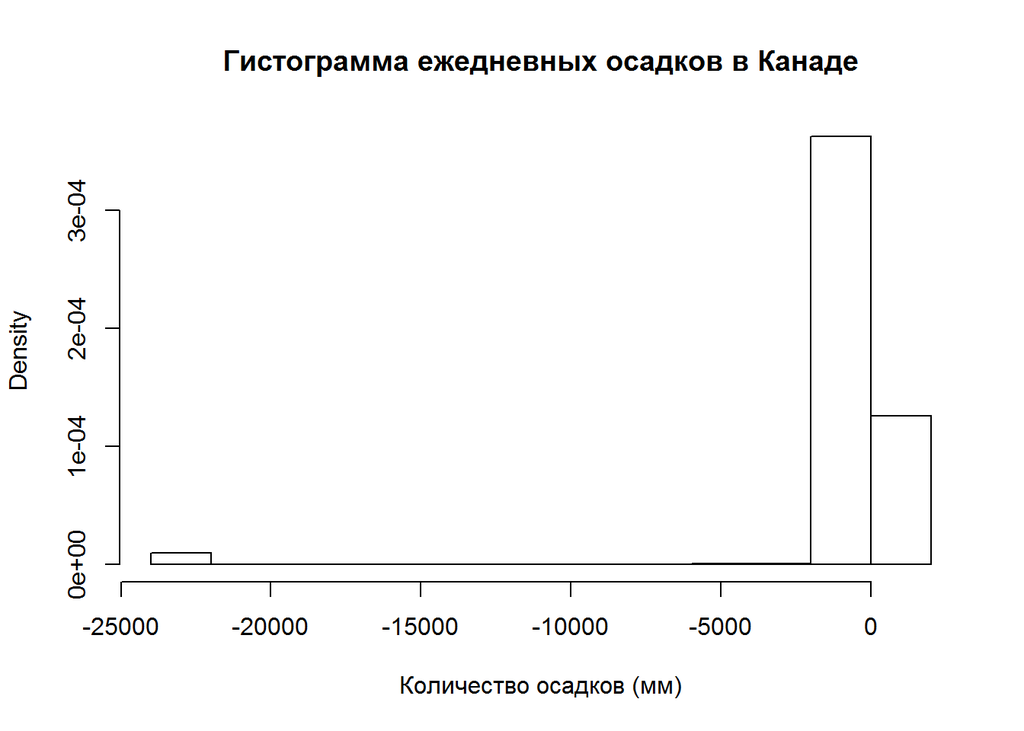

```r
daily<-c(rowSums(data.df[4:27]));
data.df<-cbind(data.df,daily=daily);
hist(data.df[,"daily"], prob = TRUE, main = "Гистограмма ежедневных осадков в Канаде",xlab="Количество осадков (мм)");
```

Выводы: полученная гистограмма не предоставляет адекватных сведений о количестве ежедневных осадков, так как среди значений колонки daily встречаются отрицательные значения, являющиеся следствием присутствия ошибочных значений в самом датафрейме. Для получения адекватных данных необходимо исключить из датафрейма все отрицательные значения (можно заменить их нулями, так как очевидно, что отрицатедльные числа (-999) ошибочно помещены в датафрейм на месте нулей).

8. Создайте новый датафрейм fixed.df, в котром исправьте замеченную ошибку. Постройте новую гистограмму, поясните, почему она более корректна.

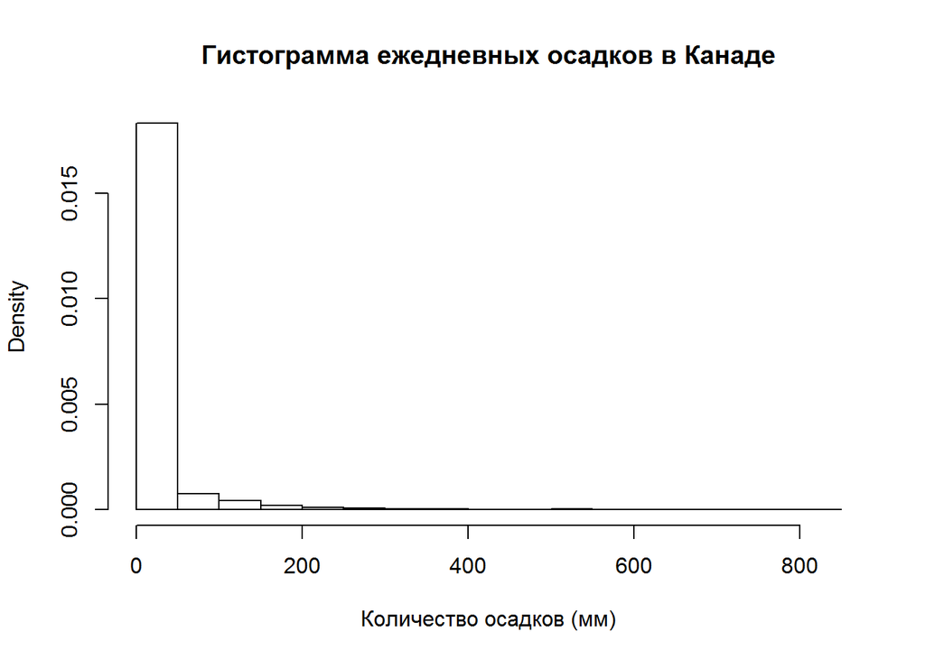

```r
fixed.df<-as.data.frame(data.df);
fixed.df[fixed.df[,]<0]<-0;
hist(fixed.df[,"daily"], prob = TRUE, main = "Гистограмма ежедневных осадков в Канаде",xlab="Количество осадков (мм)");
```

Выводы: данная гистограмма является более корректной, так как на ней отображаются только адекватные (неотрицательные) значения ежедневного количества осадков и можно проследить реальную картину.

Синтаксис и типизирование.

1. Для каждой строки кода поясните полученный результат, либо объясните почему она ошибочна.

```r
v <- c("4", "8", "15", "16", "23", "42") #создание символьного (character) вектора
max(v) #нахождение максимального значения символьного вектора. Возвращает "8", так как в данном случае производится не числовое сравнение, а посимвольное, а "8" - наибольший из символов, стоящих на первой позиции.
```

```
## [1] "8"
```

```r
sort(v) #выполнение сортировки вектора v. Сравнение также посимвольное, из чего следует полученный результат: "15" "16" "23" "4"  "42" "8".
```

```
## [1] "15" "16" "23" "4"  "42" "8"
```

```r
#sum(v) #запись ошибочна, нахождение суммы значений допустимо только для числовых, комплексных и логических аргументов.
```

2. Для следующих наборов команд поясните полученный результат, либо объясните почему они ошибочна.

```r
v2 <- c("5",7,12) #создание символьного вектора: присутствует один символьный элемент, вследствие чего тип вектора определяется как символьный.
#v2[2] + v2[3] #запись ошибочна: операции суммирования не применимы к символьным аргументам, а все значения v2 стали символьными.

df3 <- data.frame(z1="5",z2=7,z3=12) #создание датафрейма. Значения, использованные для формирования v2, записаны в таблицу, их тип сохраняется.
df3[1,2] + df3[1,3] #в случае датафрейма суммирования изначально числовых элементов возможно, так как при записи в таблицу их тип был сохранен.
```

```
## [1] 19
```

```r
l4 <- list(z1="6", z2=42, z3="49", z4=126) #создание списка из четырех элементов. В отличие от векторов в списке можно хранить одновременно различные типы данных. В список помещаются отдельные компоненты, а уже внутри этих компонентов располагаются сами элементы определенных типов, внесенные в список.
l4[[2]] + l4[[4]] #данная запись суммирования работает корректно, так как при помощи двойных квадратных скобок осуществляется извлечение элементов списка.
```

```
## [1] 168
```

```r
#l4[2] + l4[4] #данная запись ошибочна, так как применение одиночных квадратных скобок возвращает лишь ссылку на компонент списка, а не само значение.
```

Работа с функциями и операторами.

1. Оператор двоеточие создаёт последовательность целых чисел по порядку. Этот оператор — частный случай функции seq(), которую вы использовали раньше. Изучите эту функцию, вызвав команду ?seq. Испольуя полученные знания выведите на экран:
- Числа от 1 до 10000 с инкрементом 372.
- Числа от 1 до 10000 длиной 50.

```r
seq(1,10000,by=372);
```

```
##  [1]    1  373  745 1117 1489 1861 2233 2605 2977 3349 3721 4093 4465 4837
## [15] 5209 5581 5953 6325 6697 7069 7441 7813 8185 8557 8929 9301 9673
```

```r
seq(1,10000,length.out = 50);
```

```
##  [1]     1.0000   205.0612   409.1224   613.1837   817.2449  1021.3061
##  [7]  1225.3673  1429.4286  1633.4898  1837.5510  2041.6122  2245.6735
## [13]  2449.7347  2653.7959  2857.8571  3061.9184  3265.9796  3470.0408
## [19]  3674.1020  3878.1633  4082.2245  4286.2857  4490.3469  4694.4082
## [25]  4898.4694  5102.5306  5306.5918  5510.6531  5714.7143  5918.7755
## [31]  6122.8367  6326.8980  6530.9592  6735.0204  6939.0816  7143.1429
## [37]  7347.2041  7551.2653  7755.3265  7959.3878  8163.4490  8367.5102
## [43]  8571.5714  8775.6327  8979.6939  9183.7551  9387.8163  9591.8776
## [49]  9795.9388 10000.0000
```

2. Функция rep() повторяет переданный вектор указанное число раз. Объясните разницу между rep(1:5,times=3) и rep(1:5, each=3).

```r
rep(1:5,times=3); #при использовании данного выражения запись заданного вектора дублируется три раза.
```

```
##  [1] 1 2 3 4 5 1 2 3 4 5 1 2 3 4 5
```

```r
rep(1:5, each=3); #при использовании данного выражения каждый элемент заданного вектора при записи дублируется три раза.
```

```
##  [1] 1 1 1 2 2 2 3 3 3 4 4 4 5 5 5
```